# HomeWork_3

Lohit Marla

2023-09-24

1.a.

```r
probability <- 0.025  # This is for a one-tailed test with alpha = 0.05

# Use qnorm to find the z-score
z_score <- qnorm( probability)  # Use 1 - probability for a one-tailed test

# Display the z-score
cat("Z-Score (z(0.025)): ", z_score, "\n")
```

```
## Z-Score (z(0.025)):  -1.959964
```

1.b.

```r
probability <- 0.975  # This is for a one-tailed test with alpha = 0.05

# Use qnorm to find the z-score
z_score <- qnorm(probability)  # Use 1 - probability for a one-tailed test

# Display the z-score
cat("Z-Score (z(0.975)): ", z_score, "\n")
```

```
## Z-Score (z(0.975)):  1.959964
```

1.c.

```r
n1 <- 11
n2 <- 13
alpha = 0.05
# Calculate the degrees of freedom
df <- n1 + n2 - 2

# Find the critical t-value for a 95% confidence interval
critical_t_value <- qt((1- alpha )/ 2, df)
# Display the critical t-value
cat("Critical t-Value:", critical_t_value, "\n")
```

```
## Critical t-Value: -0.06342606
```

1.d.

```r
chi_squared_value <- qchisq(0.95, 17)
# Display the chi-squared value
cat("Chi-Squared Value:", chi_squared_value, "\n")
```

```
## Chi-Squared Value: 27.58711
```

1.e.

```r
# Define the alpha level

# Define the numerator degrees of freedom (df_B)
df_B <- 4

# Define the denominator degrees of freedom (df_W)
df_W <- 18

# Calculate the critical F-value using the qf() function
critical_F <- qf(0.95, df_B, df_W)

# Display the critical F-value
cat("Critical F-Value:", critical_F, "\n")
```

```
## Critical F-Value: 2.927744
```

2.a. Arthritis data set contains information about the participants with two categories of **Treatment** column where one is placebo and the other is treated along with their results which as incorporated in the column **Improved** which is a factor variable such as None, Some and Marked. It also has data related to the participant id, sex, age.

```r
# Define the alpha level
library("vcd")
data("Arthritis")
str(Arthritis)
```

```
## 'data.frame':    84 obs. of  5 variables:
##  $ ID       : int  57 46 77 17 36 23 75 39 33 55 ...
##  $ Treatment: Factor w/ 2 levels "Placebo","Treated": 2 2 2 2 2 2 2 2 2 2 ...
##  $ Sex      : Factor w/ 2 levels "Female","Male": 2 2 2 2 2 2 2 2 2 2 ...
##  $ Age      : int  27 29 30 32 46 58 59 59 63 63 ...
##  $ Improved : Ord.factor w/ 3 levels "None"<"Some"<..: 2 1 1 3 3 3 1 3 1 1 ...
```

Below code converted the Some, Marked column values of the Improved column to Improved whereas the none remains the same.

```r
#Marking all the Some and Marked to Improved whereas none remains none.
Arthritis$Improved <- as.character(Arthritis$Improved)
Arthritis$Improved[Arthritis$Improved %in% c("Some", "Marked")] <- "Improved"
Arthritis$Improved <- ordered(Arthritis$Improved, levels = c("None", "Improved"))
Arthritis$Improved
```

```
##  [1] Improved None     None     Improved Improved Improved None     Improved
##  [9] None     None     None     Improved None     Improved None     None
## [17] Improved None     Improved None     Improved Improved Improved Improved
## [25] Improved Improved Improved None     Improved Improved Improved Improved
## [33] Improved Improved Improved Improved Improved Improved None     Improved
## [41] Improved None     None     None     None     None     None     None
## [49] None     None     None     Improved None     None     None     Improved
## [57] None     Improved None     None     None     None     None     None
## [65] None     None     None     None     Improved Improved None     Improved
## [73] Improved Improved Improved None     Improved None     Improved None
## [81] None     Improved Improved Improved
## Levels: None < Improved
```

2.a. Following code cross tabs the arthritis data to baded on the **treatment** and **Improvement** into the rows=2 and columns=2. Row and columns sums were also included.

```r
(A.table <- xtabs( ~ Treatment + Improved, data = Arthritis))
```

```
##          Improved
## Treatment None Improved
##   Placebo   29       14
##   Treated   13       28
```

```r
(rsums <- margin.table(A.table, 1)) # using index 1
```

```
## Treatment
## Placebo Treated
##      43      41
```

```r
(csums <- margin.table(A.table, 2))
```

```
## Improved
##     None Improved
##       42       42
```

```r
# using index 1
```

2.b. Following code computes the true proportions of Improved patients in the Treated and Placebo groups respectively

```r
prop.table(table(Arthritis$Treatment, Arthritis$Improved), margin=1)
```

```
##
##                None  Improved
##   Placebo 0.6744186 0.3255814
##   Treated 0.3170732 0.6829268
```

From the above results it is clear that the most proportion of the data under the treaded category has more improvement when compared to the placebo.

From the below chart we can observe that Treated patients were majorly improved with respect to the Placebo treatment.

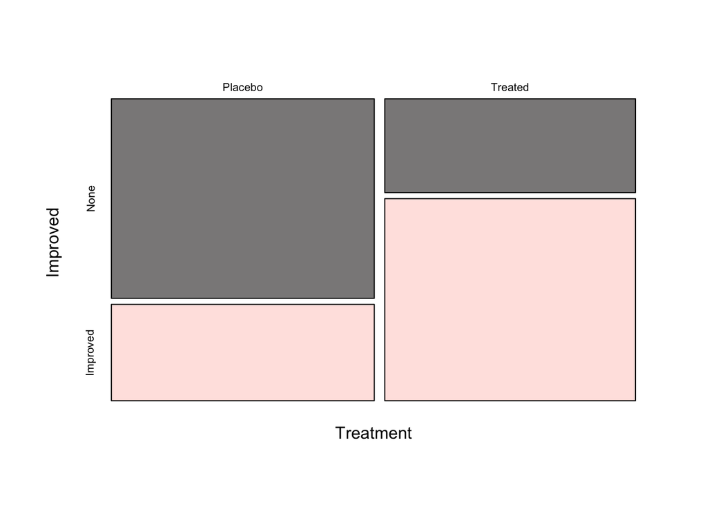

```r
mosaicplot(A.table, color = c( "snow4", "mistyrose1"),
           main = "")
```

2.c.

```r
# Define the sample proportions and sample sizes
p1 <- 0.682926829  # sample proportion for Treated group
p2 <- 0.325581395  # sample proportion for Placebo group
n_1 <- 41   # the sample size for Treated group
n_2 <- 43    # the sample size for Placebo group

# Define the desired confidence level
confidence_level <- 0.95

# Calculate the critical value (Z_alpha/2) for the desired confidence level
alpha <- 1 - confidence_level
Z_alpha_2 <- qnorm(1 - alpha / 2)

# Calculate the standard error
standard_error <- sqrt((p1 * (1 - p1) / n_1) + (p2 * (1 - p2) / n_2))

# Calculate the margin of error
margin_of_error <- Z_alpha_2 * standard_error

# Calculate the 95% confidence interval
lower_limit <- (p1 - p2) - margin_of_error
upper_limit <- (p1 - p2) + margin_of_error

# Print the confidence interval
cat("95% Confidence Interval for (p1 - p2): [", lower_limit, ",", upper_limit, "]\n")
```

```
## 95% Confidence Interval for (p1 - p2): [ 0.1575841 , 0.5571068 ]
```

The above interval which are critical values indicates the fail to reject the null hypothesis zone where if the p-value lies in between the values and if it lies beyond it we can reject the null hypothesis.

2.d.

$$H_{0} : ( \pi_{1|1} = \pi_{1|2} )$$
{#eq-onefactorH0}

versus the alternative hypothesis

$$H_{1} : ( \pi_{1|1} \ne \pi_{1|2} )$$
{#eq-onefactorH1}

Confidence Interval: 95%

```r
(cstest <- chisq.test(A.table))
```

```
##
##  Pearson's Chi-squared test with Yates' continuity correction
##
## data:  A.table
## X-squared = 9.3386, df = 1, p-value = 0.002244
```

3.a.

```r
# Define the alpha level
data("Arthritis")
str(Arthritis)
```

```
## 'data.frame':    84 obs. of  5 variables:
##  $ ID       : int  57 46 77 17 36 23 75 39 33 55 ...
##  $ Treatment: Factor w/ 2 levels "Placebo","Treated": 2 2 2 2 2 2 2 2 2 2 ...
##  $ Sex      : Factor w/ 2 levels "Female","Male": 2 2 2 2 2 2 2 2 2 2 ...
##  $ Age      : int  27 29 30 32 46 58 59 59 63 63 ...
##  $ Improved : Ord.factor w/ 3 levels "None"<"Some"<..: 2 1 1 3 3 3 1 3 1 1 ...
```

```r
Arthritis$Improved <- as.character(Arthritis$Improved)
Arthritis$Improved[Arthritis$Improved %in% c("Some", "Marked")] <- "Improved"
Arthritis$Improved <- ordered(Arthritis$Improved, levels = c("None", "Improved"))
Arthritis$Improved
```

```
##  [1] Improved None     None     Improved Improved Improved None     Improved
##  [9] None     None     None     Improved None     Improved None     None
## [17] Improved None     Improved None     Improved Improved Improved Improved
## [25] Improved Improved Improved None     Improved Improved Improved Improved
## [33] Improved Improved Improved Improved Improved Improved None     Improved
## [41] Improved None     None     None     None     None     None     None
## [49] None     None     None     Improved None     None     None     Improved
## [57] None     Improved None     None     None     None     None     None
## [65] None     None     None     None     Improved Improved None     Improved
## [73] Improved Improved Improved None     Improved None     Improved None
## [81] None     Improved Improved Improved
## Levels: None < Improved
```

```r
library(epitools)
A.table <- xtabs( ~ Treatment + Improved, data = Arthritis)

total_treated_improved <- A.table["Treated", ]['Improved']
total_placebo_improved <- A.table["Placebo", ]['Improved']
total_treated_none <- A.table["Treated", ]['None']
total_placebo_none <- A.table["Placebo", ]['None']

w1 = total_placebo_improved  / total_placebo_none
w2 = total_treated_improved  /  total_treated_none

print(w1)
```

```
##  Improved
## 0.4827586
```

```r
print(w2)
```

```
## Improved
## 2.153846
```

From the above result, Sample odds for placebo group is 0.48 where for treated it is 2.15. We can conclude that for every 0.48 improved for every one person who did not improved in the placebo group and that 2.15 persons improved for every one person did not improved in the treated group.

3.b.

```r
sample_odds_ratio = w1/w2
print(sample_odds_ratio)
```

```
##  Improved
## 0.2241379
```

The odds ratio is 1:0.22, hence the ratio is not equal to 1.

4.a.

```r
library("ACSWR")
data("tensile")
str(tensile)
```

```
## 'data.frame':    25 obs. of  4 variables:
##  $ Test_Sequence   : int  1 2 3 4 5 6 7 8 9 10 ...
##  $ Run_Number      : int  8 18 10 23 17 5 14 6 15 20 ...
##  $ CWP             : int  20 30 20 35 30 15 25 20 25 30 ...
##  $ Tensile_Strength: int  12 19 17 7 25 7 14 12 18 22 ...
```

```r
tensile$CWP <- as.factor(tensile$CWP)
str(tensile$CWP)
```

```
##  Factor w/ 5 levels "15","20","25",..: 2 4 2 5 4 1 3 2 3 4 ...
```

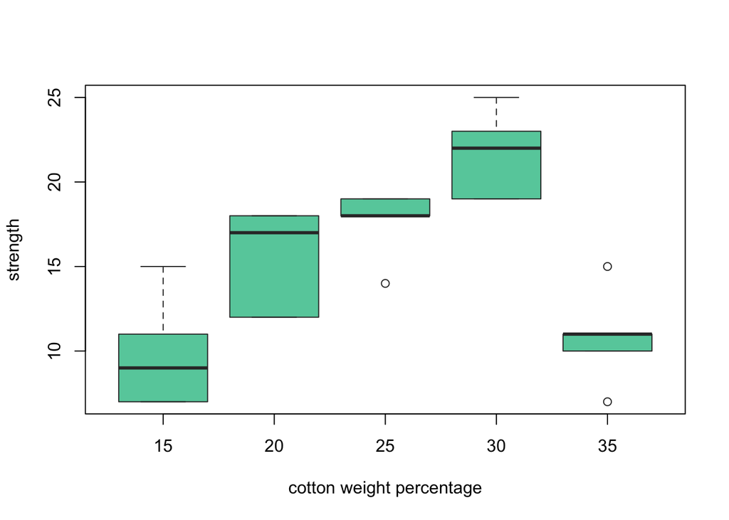

```r
boxplot(tensile$Tensile_Strength ~ tensile$CWP, xlab="cotton weight percentage",
        ylab="strength", border = "grey20", col="aquamarine3")
```

From the above chart we draw some information that the temsile strength was increased from the cwp 15% to 30% and got declined at the 35 CWP. At 15% of CWP values got extended till 15 for strength and the data looks normal whereas remaining all the other cwp from 20%-35% the data is skewed along with the outlier for 25% and 35%.

4.b.

As bartlett_test_result relies on the normlaity assumption first test for the normality

```r
#checking normality assumptions for Bartlett's Test

unique_levels <- unique(tensile$CWP)

# Perform Shapiro-Wilk test for normality for each CWP level
for(level in unique_levels) {
  subset_data <- tensile[tensile$CWP == level, ]
  shapiro_test <- shapiro.test(subset_data$Tensile_Strength)
  cat(paste("CWP Level:", level, " - p-value:", shapiro_test$p.value, "\n"))
}
```

```
## CWP Level: 20  - p-value: 0.0322816051567101
## CWP Level: 30  - p-value: 0.421149656082093
## CWP Level: 35  - p-value: 0.679901851799461
## CWP Level: 15  - p-value: 0.314039557109439
## CWP Level: 25  - p-value: 0.0233242868158401
```

```r
bartlett_test_result <- bartlett.test(tensile$Tensile_Strength, tensile$CWP)
bartlett_test_result
```

```
##
##  Bartlett test of homogeneity of variances
##
## data:  tensile$Tensile_Strength and tensile$CWP
## Bartlett's K-squared = 0.93309, df = 4, p-value = 0.9198
```

```r
library("car")
#Levene's test to check equal variance assumption
leveneTest_result <- leveneTest(tensile$Tensile_Strength ~ tensile$CWP, data = tensile)
leveneTest_result
```

```
## Levene's Test for Homogeneity of Variance (center = median)
##       Df F value Pr(>F)
## group  4  0.3179 0.8626
##       20
```

From the above two tests p-values is large and from that we can assume that the variances are equal of all the 5 populatoins. Unlike Bartlett’s test, which also tests whether the variances are equal, Levene’s test is more robust to departures from normality of the responses (and residuals). As Bartlett’s assumes the data in the each group is normally distributed and so it is more sensitive to departures from normality on the other side Levene’s test is less sensitive from the normality because it uses medians and absolute deviations from the median rather than the means and squared deviations. Moreover, data has outliers and bartlett’s test is more sensitive to the outliers where levene’s is less effected by them.

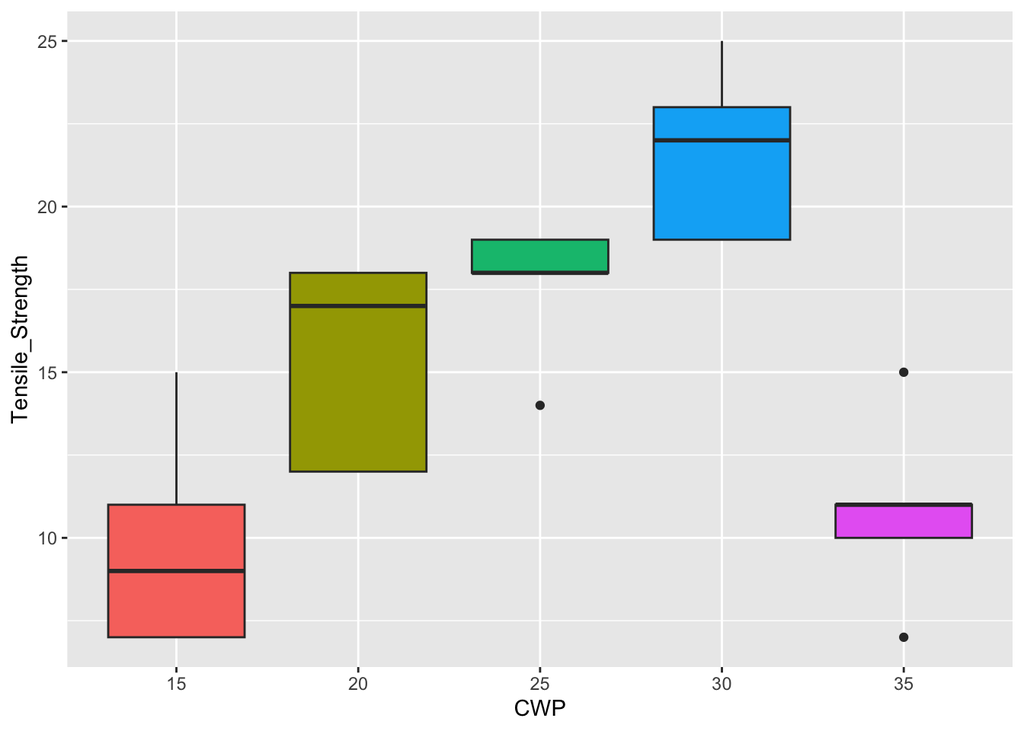

```r
library(ggplot2)

ggplot(tensile, aes(x=CWP,  y=Tensile_Strength, fill=CWP)) +
   geom_boxplot(show.legend = F)
```

From the above chart we draw some information that the temsile strength was increased from the cwp 15% to 30% and got declined at the 35 CWP. At 15% of CWP values got extended till 15 for strength and the data looks normal whereas remaining all the other cwp from 20%-35% the data is skewed along with the outlier for 25% and 35%.

4.c.

The mean tensile strengths are the same for each level of CWP where each level is the population. The null hypothesis $H_0$ is

$$H_{0}:\mu_1=\mu_2=\mu_3=\mu_4=\mu_5$$
{#eq-onefactorH0}

versus the alternative hypothesis

$$H_{1}: \mbox{ not all means } \mu_{i} \mbox{ are equal}$$
{#eq-onefactorH1}

or

$$H_{1}: \mbox{ at least one } \mu_{i} \mbox{ is different from the
others.}$$
{#eq-onefactorH1a}

$$\mu_1 :$$
Mean tensile strength at the 15% CWP
$$\mu_2 :$$
Mean tensile strength at the 20% CWP
$$\mu_3 :$$
Mean tensile strength at the 25% CWP
$$\mu_4 :$$
Mean tensile strength at the 30% CWP
$$\mu_5 :$$
Mean tensile strength at the 35% CWP

Equivalently, we write the null and alternative hypotheses in terms of $\tau$ effects as

$$H_{0}: \tau_1=\tau_2=\tau_3=\tau_4=\tau_5$$
{#eq-onefactorH0b}

versus

$$H_{1}:\mbox{ not all treatment effects } \tau_{i} \mbox{ are equal},$$
{#eq-onefactorH1b}

or

$$H_{1}: \mbox{ at least one } \tau_{i} \mbox{ is different from the
others.}$$
{#eq-onefactorH1c}

4.d.

```r
aovmod <- aov(Tensile_Strength ~ factor(CWP), data = tensile)
summary(aovmod)
```

```
##             Df Sum Sq Mean Sq F value   Pr(>F)
## factor(CWP)  4  475.8  118.94   14.76 9.13e-06 ***
## Residuals   20  161.2    8.06
## ---
## Signif. codes:  0 '***' 0.001 '**' 0.01 '*' 0.05 '.' 0.1 ' ' 1
```

Smaller P-value rejects the null hypothesis of equal means of all 5 populations and conclude that atleast one population mean is different from others. However, with this test we cannot find out the pairs whose means are unequal. There are other tests related to it such as Tukeys procedure, Bonferroni Procedure.

Lets go with the Tukeys procudre.

```r
#pairwise comparisons Tukey's HSD test
TukeyHSD(aovmod)
```

```
##   Tukey multiple comparisons of means
##     95% family-wise confidence level
##
## Fit: aov(formula = Tensile_Strength ~ factor(CWP), data = tensile)
##
## $`factor(CWP)`
##        diff         lwr        upr     p adj
## 20-15   5.6   0.2270417 10.9729583 0.0385024
## 25-15   7.8   2.4270417 13.1729583 0.0025948
## 30-15  11.8   6.4270417 17.1729583 0.0000190
## 35-15   1.0  -4.3729583  6.3729583 0.9797709
## 25-20   2.2  -3.1729583  7.5729583 0.7372438
## 30-20   6.2   0.8270417 11.5729583 0.0188936
## 35-20  -4.6  -9.9729583  0.7729583 0.1162970
## 30-25   4.0  -1.3729583  9.3729583 0.2101089
## 35-25  -6.8 -12.1729583 -1.4270417 0.0090646
## 35-30 -10.8 -16.1729583 -5.4270417 0.0000624
```

```r
#pairwise comparisons Tukey's HSD test
pairwise.t.test(tensile$Tensile_Strength, tensile$CWP,
            p.adjust.method = "bonf")
```

```
##
##  Pairwise comparisons using t tests with pooled SD
##
## data:  tensile$Tensile_Strength and tensile$CWP
##
##    15      20     25     30
## 20 0.0541  -      -      -
## 25 0.0031  1.0000 -      -
## 30 2.1e-05 0.0251 0.3754 -
## 35 1.0000  0.1859 0.0116 7.0e-05
##
## P value adjustment method: bonferroni
```

```r
aovfits <- fitted(aovmod)
aovfits
```

```
##    1    2    3    4    5    6    7    8    9   10   11   12   13   14   15   16
## 15.4 21.6 15.4 10.8 21.6  9.8 17.6 15.4 17.6 21.6 15.4  9.8 17.6 15.4  9.8 10.8
##   17   18   19   20   21   22   23   24   25
## 10.8 17.6  9.8 17.6 10.8 21.6 10.8 21.6  9.8
```

Above values are the estimated values by the anova model for each observation in the dataset.

4.e.

```r
aovres <- residuals(aovmod)
aovres
```

```
##    1    2    3    4    5    6    7    8    9   10   11   12   13   14   15   16
## -3.4 -2.6  1.6 -3.8  3.4 -2.8 -3.6 -3.4  0.4  0.4  2.6 -2.8  0.4  2.6  5.2 -0.8
##   17   18   19   20   21   22   23   24   25
##  0.2  1.4  1.2  1.4  4.2 -2.6  0.2  1.4 -0.8
```

Residuals are the difference between the observed values and the predicted/fitted values of the dependent variables based on the Anova model.

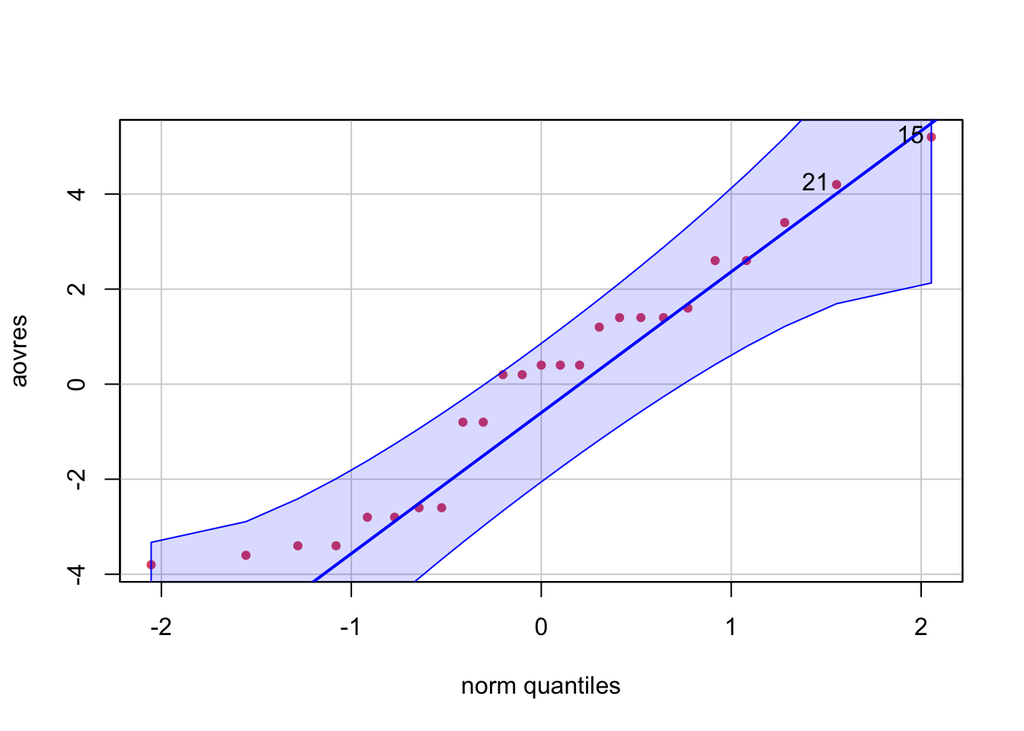

```
## [1] 15 21
```

```r
car::qqPlot(aovres, main = NA, pch = 19, col = 2, cex = 0.7)
```

In the normal Q-Q plot of the residuals using the car::qqPlot() function, the residuals seem to fall along a straight line.

```r
shapiro.test(aovres)
```

```
##
##  Shapiro-Wilk normality test
##
## data:  aovres
## W = 0.94387, p-value = 0.1818
```

Normality assumption holds on the residuals as the p-value is greater than 0.05.

5. **Cherry Picking:** It is an immoral attempt which was done intensionaly by the researcher to not disclose entire results of the testing and to choose only the ones which best support the hypothesis favorablly and hiding the unfavourable arguments. It misleads the conception about the findings and could result in various adverse effects on the public, organization etc, which inturn effcts the image of the publicatoins, researcher and the organization involved in it.

Cheery picking is an unethical practise in many ways:

1. **Misrepresentation of reality:** It distrots the true picture of the data and can misinterpret the reality by selecting the favourable results, it creates a biased and inaccurate representation of the inaccurate data.
2. **Confirmation Bias:** It reinforces confirmation bias, which is the tendency to search for, interpret, and remember information that confirms one’s preconceptions or beliefs. Cherry-picking can lead to the unjustified confirmation of preexisting beliefs.
3. **Deceptive or Manipulative:** When researchers or analysts selectively present data or results, it can deceive readers, decision-makers, or the public into making incorrect judgments or decisions. This manipulation is unethical as it undermines informed decision-making.
4. **Loss of Trust:** Engaging in cherry-picking erodes trust in research, analysis, or reporting. When stakeholders or the public discover that information has been selectively presented, they may lose confidence in the credibility of the source.
5. **Publication Bias:** In scientific research, cherry-picking can lead to publication bias, where only studies with positive or significant results are published while studies with null or negative findings remain unpublished. This distorts the scientific literature and can lead to incomplete knowledge in a field.
6. **Policy Implications:** In policymaking, cherry-picking can have serious consequences. Selectively presenting data to support a policy agenda, while ignoring data that contradicts it, can lead to poorly informed policies that do not address real issues.
7. **Ethical Violation:** Cherry-picking violates ethical principles in research and analysis, such as honesty, transparency, and integrity. It undermines the commitment to provide an accurate and unbiased representation of data.

**Example** to illustrates the above described issue, there is a reputated organizatoin who has their business expansion in the field of healthcare and was recently marketed their new product related to the blood tissue cancer detection claming that their product can detect the cancer from the blood tissue data with accuracy 80% and also has no side-effects. However, researchers outside the organization conducted a test and found that their product is only 60% accurate considering all the scenarios and variables related to it and concluded that the organization has done **Misrepresentation of reality** also they suggessted some possible side-effects with proof where initially company has hidied about it in promotional events. After, this was published in the news journals, online blogs and newspapers **trustworthy** about the organization was heavily effected, sales were down for remaining products from them also some of the customers who bought the product was also in panic. So, from the above example it is clear that the company has cherry-picked by hiding the side-effects of the product as well as supportive data to argue their claims of 80% accuracy.